# Аналитика мобильного приложения стартапа.

## Описание проекта

```
Данные предоставлены стартапом по продажам продуктов питания.

Необходимо разобраться как ведут себя пользователи мобильного приложения магазина.

Задача проекта:

1.изучить воронку продаж (как пользователи доходят до покупки, сколько пользователей застревает, на каких "шагах" застревает пользователь)

2.исследовать результаты А/А/В - теста. В группу В попали пользователия, которые видят новый шифр в приложении. Выяснить, повлияло ли изменение шифра на поведение пользователей.
```

## Общая информация

### Подключим библиотеки

```python
import pandas as pd
import scipy.stats as stats
import datetime as dt
import numpy as np
from matplotlib import pyplot as plt
from pandas.plotting import register_matplotlib_converters
import warnings
register_matplotlib_converters()
import seaborn as sns
```

### Прочитаем данные

```python
try:
    df = pd.read_csv('C:/Users/User/Desktop/Практикум/Сборный проект 2/logs_exp.csv', sep='\t')
except:
    df = pd.read_csv('/datasets/logs_exp.csv', sep='\t')
df.head(5)
```

|  | EventName | DeviceIDHash | EventTimestamp | ExpId |
| --- | --- | --- | --- | --- |
| 0 | MainScreenAppear | 4575588528974610257 | 1564029816 | 246 |
| 1 | MainScreenAppear | 7416695313311560658 | 1564053102 | 246 |
| 2 | PaymentScreenSuccessful | 3518123091307005509 | 1564054127 | 248 |
| 3 | CartScreenAppear | 3518123091307005509 | 1564054127 | 248 |
| 4 | PaymentScreenSuccessful | 6217807653094995999 | 1564055322 | 248 |

### Описание данных

• EventName — название события;

• DeviceIDHash — уникальный идентификатор пользователя

• EventTimestamp — время события;

• ExpId — номер эксперимента: 246 и 247 — контрольные группы, а 248 — экспериментальная.

```python
print (df.info())
```

```
<class 'pandas.core.frame.DataFrame'>
RangeIndex: 244126 entries, 0 to 244125
Data columns (total 4 columns):
 #   Column          Non-Null Count   Dtype
---  ------          --------------   -----
 0   EventName       244126 non-null  object
 1   DeviceIDHash    244126 non-null  int64
 2   EventTimestamp  244126 non-null  int64
 3   ExpId           244126 non-null  int64
dtypes: int64(3), object(1)
memory usage: 7.5+ MB
None
```

```python
print(df.isnull().sum())
```

```
EventName         0
DeviceIDHash      0
EventTimestamp    0
ExpId             0
dtype: int64
```

```python
df.describe(include = "all")
```

|  | EventName | DeviceIDHash | EventTimestamp | ExpId |
| --- | --- | --- | --- | --- |
| count | 244126 | 2.441260e+05 | 2.441260e+05 | 244126.000000 |
| unique | 5 | NaN | NaN | NaN |
| top | MainScreenAppear | NaN | NaN | NaN |
| freq | 119205 | NaN | NaN | NaN |
| mean | NaN | 4.627568e+18 | 1.564914e+09 | 247.022296 |
| std | NaN | 2.642425e+18 | 1.771343e+05 | 0.824434 |
| min | NaN | 6.888747e+15 | 1.564030e+09 | 246.000000 |
| 25% | NaN | 2.372212e+18 | 1.564757e+09 | 246.000000 |
| 50% | NaN | 4.623192e+18 | 1.564919e+09 | 247.000000 |
| 75% | NaN | 6.932517e+18 | 1.565075e+09 | 248.000000 |
| max | NaN | 9.222603e+18 | 1.565213e+09 | 248.000000 |

```python
df['ExpId'].nunique()
```

```
3
```

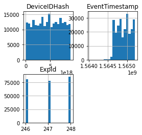

```python
df.hist(bins= 20, figsize=(4,4));
```

### Вывод:

В файле logs_exp.csv даны 4 столбца и 244126 строчки. Пропусков в данных нет.

В колонке ExpId три группы 246-248, как и было указано в описании.

Колонка EventName содержит 5 уникальных названий событий.

Колонка с данными о датах выглядит странно на гистограмме, даже с учетом того что данные не приведены к нужному типу.

Необходимо:

- привести к "змеиному" регистру наименования столбцов или переименовать
- привести даты к необходимому типу данных
- проверить дубликаты

## Предобработка данных

### Заменим названия столбцов

```python
df.columns = ['event', 'user_id', 'date_time', 'group']
df.head(3)
```

|  | event | user_id | date_time | group |
| --- | --- | --- | --- | --- |
| 0 | MainScreenAppear | 4575588528974610257 | 1564029816 | 246 |
| 1 | MainScreenAppear | 7416695313311560658 | 1564053102 | 246 |
| 2 | PaymentScreenSuccessful | 3518123091307005509 | 1564054127 | 248 |

### Изменить тип данных в столбце date_time

```python
df['date_time'] = pd.to_datetime(df['date_time'], unit='s')
df.head(2)
```

|  | event | user_id | date_time | group |
| --- | --- | --- | --- | --- |
| 0 | MainScreenAppear | 4575588528974610257 | 2019-07-25 04:43:36 | 246 |
| 1 | MainScreenAppear | 7416695313311560658 | 2019-07-25 11:11:42 | 246 |

### Добавить колонку даты

```python
df['date'] = pd.to_datetime(df['date_time'].dt.date)
df.head(2)
```

|  | event | user_id | date_time | group | date |
| --- | --- | --- | --- | --- | --- |
| 0 | MainScreenAppear | 4575588528974610257 | 2019-07-25 04:43:36 | 246 | 2019-07-25 |
| 1 | MainScreenAppear | 7416695313311560658 | 2019-07-25 11:11:42 | 246 | 2019-07-25 |

### Проверим дубликаты

```python
df.duplicated().sum()
```

```
413
```

```python
#удалим дубликаты
df = df.drop_duplicates().reset_index(drop=True)
```

```python
# проверим, есть ли пользователи в разных группах одновременно:
df.groupby('user_id').agg({'group':'nunique'}).sort_values(by='group', ascending=False)
```

| user_id | group |
| --- | --- |
| 6888746892508752 | 1 |
| 6207768971558512760 | 1 |
| 6217807653094995999 | 1 |
| 6217295124800833842 | 1 |
| 6216080220799726690 | 1 |
| ... | ... |
| 3175239243679501019 | 1 |
| 3171891164497446149 | 1 |
| 3171454373076660766 | 1 |
| 3170212200647575044 | 1 |
| 9222603179720523844 | 1 |

7551 rows × 1 columns

### Вывод

- Заменили названия столбцов на более удобные
- Заменили тип данных в столбце date_time
- Добавили столбец с датой
- Удалили 413 дубликатов
- ID пользователей, участвующих в двух или более группах - нет

## Изучим и проверим данные

### Количество событий, пользователей

```python
print('Перед нами данные с {} по {}.'.format(df['date_time'].min(),df['date_time'].max()))
print('')
print('Всего событий в логе {}.'.format(df['user_id'].count()))
event_befor = df['user_id'].count()
print('')
print('Всего пользователей в логе {}.'.format(df['user_id'].nunique()))
user_befor = df['user_id'].nunique()
print('')

# в среднем событий приходится на пользователя
event_mean = round(df.groupby('user_id').agg({'event':'count'}).mean(),0)
print('Количество событий на пользователя в среднем {}.'.format(event_mean))
```

```
Перед нами данные с 2019-07-25 04:43:36 по 2019-08-07 21:15:17.

Всего событий в логе 243713.

Всего пользователей в логе 7551.

Количество событий на пользователя в среднем event    32.0
dtype: float64.
```

```python
# распределение событий по пользователям
event_mean = df.groupby('user_id').agg({'event':'count'})
event_mean.describe()
```

|  | event |
| --- | --- |
| count | 7551.000000 |
| mean | 32.275593 |
| std | 65.154219 |
| min | 1.000000 |
| 25% | 9.000000 |
| 50% | 20.000000 |
| 75% | 37.000000 |
| max | 2307.000000 |

Среднее количество событий на пользователя составляет 32 события,

при этом медиана 20 событий

есть аномально большое кольчество событий на одного пользователя 2307

### Гистограмма событий по дате

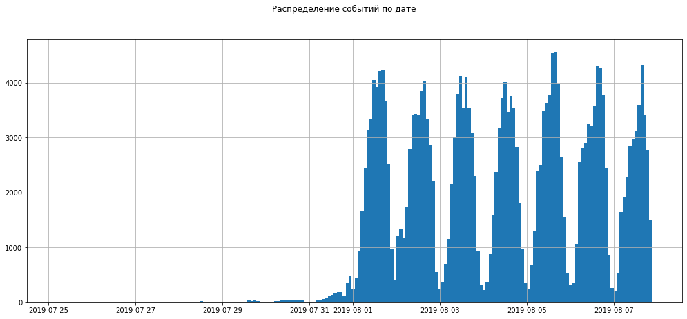

```python
# гистограмма по дате и времени
df['date_time'].hist(bins=200,figsize=(17, 7))
plt.suptitle('Распределение событий по дате');
```

Данные за первую неделю практически отсутствуют, поэтому анализировать можно только вторую неделю.

Возьмем период с 01 августа 2019 года

### Очистка данных

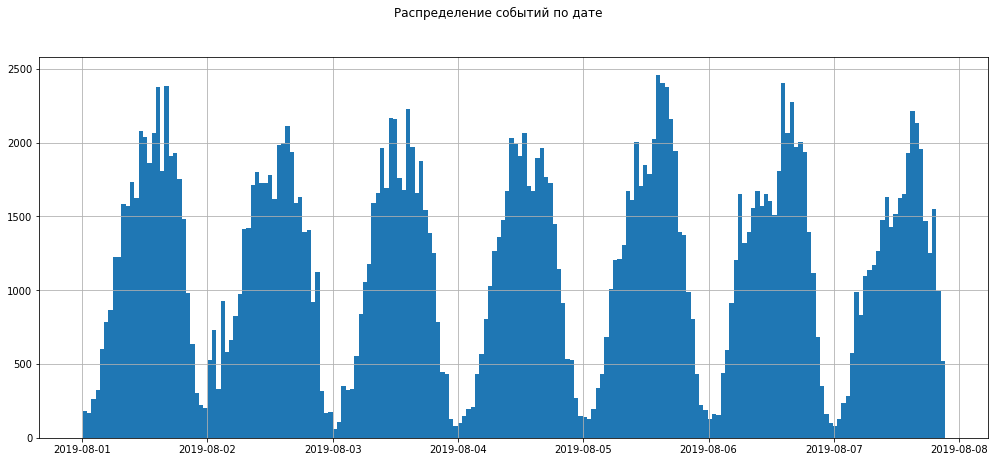

```python
# отбросим данные за июль
df = df[df['date_time']>='2019-08-01']
df['date_time'].hist(bins=200,figsize=(17, 7))
plt.suptitle('Распределение событий по дате');
```

Получили период полных данных

Видно, что активность пользователей максимальна днем и падает в ночной период

Проверим количество пользователей после оптимизации данных

```python
print('Перед нами данные с {} по {}.'.format(df['date_time'].min(),df['date_time'].max()))
print('')
print('Всего событий в логе {}.'.format(df['user_id'].count()))
print('')
print('Всего пользователей в логе {}.'.format(df['user_id'].nunique()))
print('')
print('Количество событий удаленных из данных {}, ({:.2%}).'.format(event_befor-df['user_id'].count(),
        (df['user_id'].count()/event_befor-1)))
print('')
print('Количество пользователей удаленных из данных {}, ({:.2%}).'.format(user_befor-df['user_id'].nunique(),
        (df['user_id'].nunique()/user_befor-1)))
```

```
Перед нами данные с 2019-08-01 00:07:28 по 2019-08-07 21:15:17.

Всего событий в логе 240887.

Всего пользователей в логе 7534.

Количество событий удаленных из данных 2826, (-1.16%).

Количество пользователей удаленных из данных 17, (-0.23%).
```

### Распределение пользователей по группам после очистки данных

```python
# распределены ли пользователи по всем трем группам
df['group'].nunique()
```

```
3
```

```python
df.groupby('group').agg({'user_id': 'nunique'}).rename(columns={'user_id':'count_users'})
```

| group | count_users |
| --- | --- |
| 246 | 2484 |
| 247 | 2513 |
| 248 | 2537 |

Пользователи распределены по всем трем группам, распределение равномерное

### Вывод

До очистки данных событий в логе 243713, а пользователей в логе 7551.

Количество событий на пользователя в среднем event 32.0

После очистки неполных данных осталось событий в логе 240887, а пользователей в логе 7534.

Потери данных не значительны

Распределение пользователей по группам равномерно

## Изучим воронку событий

Какие события есть в логах, как часто они встречаются. Отсортируйте события по частоте.

### События в логах

```python
df.head(2)
```

|  | event | user_id | date_time | group | date |
| --- | --- | --- | --- | --- | --- |
| 2826 | Tutorial | 3737462046622621720 | 2019-08-01 00:07:28 | 246 | 2019-08-01 |
| 2827 | MainScreenAppear | 3737462046622621720 | 2019-08-01 00:08:00 | 246 | 2019-08-01 |

```python
event_count = df.groupby('event').agg({'user_id':'count'}).sort_values(by='user_id',
                                                                       ascending=False)
event_count
```

| event | user_id |
| --- | --- |
| MainScreenAppear | 117328 |
| OffersScreenAppear | 46333 |
| CartScreenAppear | 42303 |
| PaymentScreenSuccessful | 33918 |
| Tutorial | 1005 |

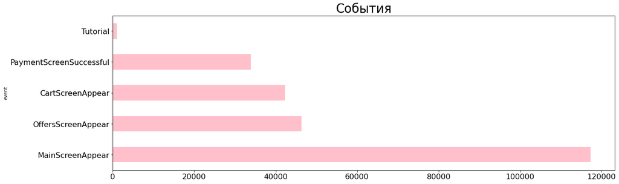

```python
event_count.plot(kind = 'barh', figsize = (19,6), legend = False, fontsize = 16, color = 'pink')
plt.title('События',size = (26));
```

В логе представлено пять вариантов событий:

MainScreenAppear - главный экран 117328 событий

OffersScreenAppear - экран с продуктами 46333 событий

CartScreenAppear - экран с корзиной 42303 событий

PaymentScreenSuccessful - экран с подтверждением оплаты 33918 событий

Tutorial - экран с обучением 1005 событий

### События и пользователи

Посчитайте, сколько пользователей совершали каждое из этих событий.

Отсортируйте события по числу пользователей.

Посчитайте долю пользователей, которые хоть раз совершали событие.

```python
df.head(2)
```

|  | event | user_id | date_time | group | date |
| --- | --- | --- | --- | --- | --- |
| 2826 | Tutorial | 3737462046622621720 | 2019-08-01 00:07:28 | 246 | 2019-08-01 |
| 2827 | MainScreenAppear | 3737462046622621720 | 2019-08-01 00:08:00 | 246 | 2019-08-01 |

```python
users_count = df.groupby('event').agg({'user_id':'nunique'}
                       ).rename(columns={'user_id' : 'users'}
                               ).sort_values(by='users',ascending=False)
users_count
```

| event | users |
| --- | --- |
| MainScreenAppear | 7419 |
| OffersScreenAppear | 4593 |
| CartScreenAppear | 3734 |
| PaymentScreenSuccessful | 3539 |
| Tutorial | 840 |

```python
users_count['per'] = round(users_count['users']/df['user_id'].nunique(),2)*100
```

```python
users_count
```

| event | users | per |
| --- | --- | --- |
| MainScreenAppear | 7419 | 98.0 |
| OffersScreenAppear | 4593 | 61.0 |
| CartScreenAppear | 3734 | 50.0 |
| PaymentScreenSuccessful | 3539 | 47.0 |
| Tutorial | 840 | 11.0 |

Предположим порядок событий

MainScreenAppear --> OffersScreenAppear --> CartScreenAppear --> PaymentScreenSuccessful

Событие Tutorial мало и не входит в цепочку событий. Предположу, что обучение можно пройти не посещая корзину и оплату. Для воронки событий уберем из расчетов Tutorial.

Первое событие MainScreenAppear совершает 98% пользователей, по данным лога. Посмотрев поведение пользователей пропустивших первое событие, видно, что можно зайти сразу на карточку товара и даже совершить покупку, не посещая последовательно все события. Скорее всего магазин размещает так баннеры, где после клика можно сразу оплатить товар или попасть на страницу товара.

### Воронка событий

По воронке событий посчитайте, какая доля пользователей проходит на следующий шаг воронки (от числа пользователей на предыдущем).

```python
users_pt = df[df['event'] != 'Tutorial'].pivot_table(
    index='user_id',
    columns='event',
    values='date_time',
    aggfunc='min')
users_pt
```

| event user_id | CartScreenAppear | MainScreenAppear | OffersScreenAppear | PaymentScreenSuccessful |
| --- | --- | --- | --- | --- |
| 6888746892508752 | NaT | 2019-08-06 14:06:34 | NaT | NaT |
| 6909561520679493 | 2019-08-06 18:52:58 | 2019-08-06 18:52:54 | 2019-08-06 18:53:04 | 2019-08-06 18:52:58 |
| 6922444491712477 | 2019-08-04 14:19:40 | 2019-08-04 14:19:33 | 2019-08-04 14:19:46 | 2019-08-04 14:19:40 |
| 7435777799948366 | NaT | 2019-08-05 08:06:34 | NaT | NaT |
| 7702139951469979 | 2019-08-02 14:28:45 | 2019-08-01 04:29:54 | 2019-08-01 04:29:56 | 2019-08-02 14:28:45 |
| ... | ... | ... | ... | ... |
| 9217594193087726423 | 2019-08-02 09:00:58 | NaT | 2019-08-02 09:01:08 | 2019-08-02 09:00:57 |
| 9219463515465815368 | 2019-08-06 16:49:40 | 2019-08-05 05:26:26 | 2019-08-06 16:48:57 | 2019-08-06 16:52:16 |
| 9220879493065341500 | 2019-08-02 17:59:16 | 2019-08-02 17:58:48 | 2019-08-02 17:59:00 | NaT |
| 9221926045299980007 | NaT | 2019-08-01 17:30:27 | NaT | NaT |
| 9222603179720523844 | NaT | 2019-08-01 06:52:13 | NaT | NaT |

7530 rows × 4 columns

```python
users_count
```

| event | users | per |
| --- | --- | --- |
| MainScreenAppear | 7419 | 98.0 |
| OffersScreenAppear | 4593 | 61.0 |
| CartScreenAppear | 3734 | 50.0 |
| PaymentScreenSuccessful | 3539 | 47.0 |
| Tutorial | 840 | 11.0 |

```python
users_count['funnel %'] = round(users_count['users']/users_count['users']
                                 .shift(1,fill_value=7419)*100,1)
users_count = users_count.reset_index().drop(4)

users_count
```

|  | event | users | per | funnel % |
| --- | --- | --- | --- | --- |
| 0 | MainScreenAppear | 7419 | 98.0 | 100.0 |
| 1 | OffersScreenAppear | 4593 | 61.0 | 61.9 |
| 2 | CartScreenAppear | 3734 | 50.0 | 81.3 |
| 3 | PaymentScreenSuccessful | 3539 | 47.0 | 94.8 |

```python
print('Посетителей на главной странице:',
      '({:.1%})'.format(users_pt['MainScreenAppear'].count()/users_pt['MainScreenAppear'].count()))
print(' ')
print('Посмотрели экран с продуктами в % от предыдущего шага:',
      '({:.1%})'.format(users_pt['OffersScreenAppear'].count()/users_pt['MainScreenAppear'].count()))
print(' ')
print('Посмотрели экран с корзиной в % от предыдущего шага:',
      '({:.1%})'.format(users_pt['CartScreenAppear'].count()/users_pt['OffersScreenAppear'].count()))
print(' ')
print('Оплатили в % от предыдущего шага:',
      '({:.1%})'.format(users_pt['PaymentScreenSuccessful'].count()/users_pt['CartScreenAppear'].count()))
```

```
Посетителей на главной странице: (100.0%)

Посмотрели экран с продуктами в % от предыдущего шага: (61.9%)

Посмотрели экран с корзиной в % от предыдущего шага: (81.3%)

Оплатили в % от предыдущего шага: (94.8%)
```

Потеря на втором шаге очень большая 39%

Стоит отметить, что посетители могут купить товар с главной страницы, не просматривая экран продукта,

вероятно это дает большую потерю

Так же интересен, например пользователь 9217594193087726423, который сначала купил продукт, потом зашел в корзину и затем на экран товара, не посещая главную страницу

```python
print('Доля пользователей от посещения главной страницы к оплате :',
      '({:.1%})'.format(users_pt['PaymentScreenSuccessful'].count()/users_pt['MainScreenAppear'].count()))
```

```
Доля пользователей от посещения главной страницы к оплате : (47.7%)
```

### Вывод

OffersScreenAppear - экран с продуктами 46333 событий и 4593 пользователя

CartScreenAppear - экран с корзиной 42303 событий и 3734 пользователя

PaymentScreenSuccessful - экран с подтверждением оплаты 33918 событий и 3539 пользователя

Tutorial - экран с обучением 1005 событий и 840 пользователя

Воронка событий выглядит следующим образом:

Посетителей на главной странице: (100.0%)

Посмотрели экран с продуктами в % от предыдущего шага: (61.9%)

Посмотрели экран с корзиной в % от предыдущего шага: (81.3%)

Оплатили в % от предыдущего шага: (94.8%)

Можно отметить, что пользователи, которые положили товар в корзину, купят товар с высокой долей вероятности.

Стоит посмотреть причину потери пользователей на втором шаге (тех.проблемы с переходом на страницу, рекламируется товар больше, чем главная страница...)

## Изучим результаты эксперимента

Сколько пользователей в каждой экспериментальной группе

```python
df_group = df.groupby('group').agg({'user_id': 'nunique'}).rename(columns={'user_id':'full_users'})
df_group
```

| group | full_users |
| --- | --- |
| 246 | 2484 |
| 247 | 2513 |
| 248 | 2537 |

### Статистическая разница между выборками

Нулевая гипотеза: стат разницы между 246 и 247 группой нет

Альтернативная гипотеза: разница между 246 и 247 группой есть

```python
group = (df.
          groupby(['event', 'group'], as_index=False).
          agg({'user_id': 'nunique'}).
          rename(columns={'user_id' : 'users'}).
          sort_values(by=['group','users'], ascending=False))

group = group[group['event'] != 'Tutorial']
group
```

|  | event | group | users |
| --- | --- | --- | --- |
| 5 | MainScreenAppear | 248 | 2493 |
| 8 | OffersScreenAppear | 248 | 1531 |
| 2 | CartScreenAppear | 248 | 1230 |
| 11 | PaymentScreenSuccessful | 248 | 1181 |
| 4 | MainScreenAppear | 247 | 2476 |
| 7 | OffersScreenAppear | 247 | 1520 |
| 1 | CartScreenAppear | 247 | 1238 |
| 10 | PaymentScreenSuccessful | 247 | 1158 |
| 3 | MainScreenAppear | 246 | 2450 |
| 6 | OffersScreenAppear | 246 | 1542 |
| 0 | CartScreenAppear | 246 | 1266 |
| 9 | PaymentScreenSuccessful | 246 | 1200 |

```python
def z_test(df1, df2, event, alpha, n):
    '''
    - df1, df2 - датафреймы с логами
    - event - событие
    - alpfa - критический уровень статистической значимости
    - n - поправка Боннферони для критического уровня статистической значимости
    '''

    # критический уровень статистической значимости c поправкой Бонферрони
    bonferroni_alpha = alpha / n

    # число пользователей в группе 1 и группе 2:
    n_users = np.array([df1['user_id'].nunique(),
                        df2['user_id'].nunique()])

    # число пользователей, совершивших событие в группе 1 и группе 2
    success = np.array([df1[df1['event'] == event]['user_id'].nunique(),
                        df2[df2['event'] == event]['user_id'].nunique()])

    # пропорции успехов в группах:
    p1 = success[0] / n_users[0]
    p2 = success[1] / n_users[1]

    # пропорция успехов в комбинированном датасете:
    p_combined = (success[0] + success[1]) / (n_users[0] + n_users[1])

    # разница пропорций в датасетах
    difference = p1 - p2

    # считаем статистику в ст.отклонениях стандартного нормального распределения
    z_value = difference /  np.sqrt(p_combined * (1 - p_combined) * (1/n_users[0] + 1/n_users[1]))

    # задаем стандартное нормальное распределение (среднее 0, ст.отклонение 1)
    distr = stats.norm(0, 1)

    p_value = (1 - distr.cdf(abs(z_value))) * 2   #тест двусторонний, удваиваем результат

    print('Событие:', event)
    print('p-значение: ', p_value)

    if p_value < bonferroni_alpha:
        print('Отвергаем нулевую гипотезу: между долями есть разница')
    else:
        print('Не получилось отвергнуть нулевую гипотезу')
```

Подготовили функцию для проверки статистически значимых различий между группами.

В теле функции применяем поправку Бонферрони, так как внутри групп мы сравниваем 4 события,

и хотим сохранить уровень значимости в заданных параметрах 5%.

```python
# статистически значимая разница между контрольными группами 246 и 247:
for event in group['event'].unique():
    z_test(df[df['group'] == 246], df[df['group'] == 247], event,.05, 16)
    print()
```

```
Событие: MainScreenAppear
p-значение:  0.7570597232046099
Не получилось отвергнуть нулевую гипотезу

Событие: OffersScreenAppear
p-значение:  0.2480954578522181
Не получилось отвергнуть нулевую гипотезу

Событие: CartScreenAppear
p-значение:  0.22883372237997213
Не получилось отвергнуть нулевую гипотезу

Событие: PaymentScreenSuccessful
p-значение:  0.11456679313141849
Не получилось отвергнуть нулевую гипотезу
```

Провели 4 сравнения выборок между группами 246 и 247.

По всем событиям, которые мы сравнивали, статист значимых различий не обнаружено и нулевую гипотезу о равенстве групп отвергнуть мы не можем.

Принимаем, что контрольные группы А\А корректны.

```python
# статистически значимая разница между контрольными группами 246 и 247:
for event in group['event'].unique():
    z_test(df[df['group'] == 246], df[df['group'] == 247], event,.30, 1)
    print()
```

```
Событие: MainScreenAppear
p-значение:  0.7570597232046099
Не получилось отвергнуть нулевую гипотезу

Событие: OffersScreenAppear
p-значение:  0.2480954578522181
Отвергаем нулевую гипотезу: между долями есть разница

Событие: CartScreenAppear
p-значение:  0.22883372237997213
Отвергаем нулевую гипотезу: между долями есть разница

Событие: PaymentScreenSuccessful
p-значение:  0.11456679313141849
Отвергаем нулевую гипотезу: между долями есть разница
```

```python
# статистически значимая разница между контрольными группами 246 и 247:
for event in group['event'].unique():
    z_test(df[df['group'] == 246], df[df['group'] == 247], event,.30, 16)
    print()
```

```
Событие: MainScreenAppear
p-значение:  0.7570597232046099
Не получилось отвергнуть нулевую гипотезу

Событие: OffersScreenAppear
p-значение:  0.2480954578522181
Не получилось отвергнуть нулевую гипотезу

Событие: CartScreenAppear
p-значение:  0.22883372237997213
Не получилось отвергнуть нулевую гипотезу

Событие: PaymentScreenSuccessful
p-значение:  0.11456679313141849
Не получилось отвергнуть нулевую гипотезу
```

### Самое популярное событие

```python
# сколько пользователей совершили самое популярное событие по группам
group_max = df[df['event'] =='MainScreenAppear']
group_m = (group_max.
          groupby(['event', 'group'], as_index=False).
          agg({'user_id': 'nunique'}).
          rename(columns={'user_id' : 'users'}))
group_m
```

|  | event | group | users |
| --- | --- | --- | --- |
| 0 | MainScreenAppear | 246 | 2450 |
| 1 | MainScreenAppear | 247 | 2476 |
| 2 | MainScreenAppear | 248 | 2493 |

```python
group_mf = group_m.merge(df_group, on='group')
```

```python
group_mf
```

|  | event | group | users | full_users |
| --- | --- | --- | --- | --- |
| 0 | MainScreenAppear | 246 | 2450 | 2484 |
| 1 | MainScreenAppear | 247 | 2476 | 2513 |
| 2 | MainScreenAppear | 248 | 2493 | 2537 |

```python
# посчитаем долю пользователей совершивших самое популярное событие
group_mf['per'] = round(group_mf['users']/group_mf['full_users'],3)
group_mf
```

|  | event | group | users | full_users | per |
| --- | --- | --- | --- | --- | --- |
| 0 | MainScreenAppear | 246 | 2450 | 2484 | 0.986 |
| 1 | MainScreenAppear | 247 | 2476 | 2513 | 0.985 |
| 2 | MainScreenAppear | 248 | 2493 | 2537 | 0.983 |

Практически все пользователи из общего числа открывали главную страницу

### Стат различие между контрольными группами и группой с измененным шифром по событиям

```python
# статистически значимая разница между группами 246 и 248:
for event in group['event'].unique():
    z_test(df[df['group'] == 246], df[df['group'] == 248], event,.05,16)
    print()
```

```
Событие: MainScreenAppear
p-значение:  0.2949721933554552
Не получилось отвергнуть нулевую гипотезу

Событие: OffersScreenAppear
p-значение:  0.20836205402738917
Не получилось отвергнуть нулевую гипотезу

Событие: CartScreenAppear
p-значение:  0.07842923237520116
Не получилось отвергнуть нулевую гипотезу

Событие: PaymentScreenSuccessful
p-значение:  0.2122553275697796
Не получилось отвергнуть нулевую гипотезу
```

Статистически значимой разницы между контрольной группой 246 и тестируемой группой 248 нет

```python
# статистически значимая разница между группами 247 и 248:
for event in group['event'].unique():
    z_test(df[df['group'] == 247], df[df['group'] == 248], event,.05,16)
    print()
```

```
Событие: MainScreenAppear
p-значение:  0.4587053616621515
Не получилось отвергнуть нулевую гипотезу

Событие: OffersScreenAppear
p-значение:  0.9197817830592261
Не получилось отвергнуть нулевую гипотезу

Событие: CartScreenAppear
p-значение:  0.5786197879539783
Не получилось отвергнуть нулевую гипотезу

Событие: PaymentScreenSuccessful
p-значение:  0.7373415053803964
Не получилось отвергнуть нулевую гипотезу
```

Статистически значимой разницы между контрольной группой 247 и тестируемой группой 248 нет

```python
# статистически значимая разница между группами 246+247 и 248:
for event in group['event'].unique():
    z_test(df[df['group'] != 248], df[df['group'] == 248], event,.05,16)
    print()
```

```
Событие: MainScreenAppear
p-значение:  0.29424526837179577
Не получилось отвергнуть нулевую гипотезу

Событие: OffersScreenAppear
p-значение:  0.43425549655188256
Не получилось отвергнуть нулевую гипотезу

Событие: CartScreenAppear
p-значение:  0.18175875284404386
Не получилось отвергнуть нулевую гипотезу

Событие: PaymentScreenSuccessful
p-значение:  0.6004294282308704
Не получилось отвергнуть нулевую гипотезу
```

Статистически значимой разницы между суммой 246 и 247 группами и тестируемой группой 248 нет

Тестируемая группа 248 не дает значимых различий с контрольными группами, что говорит о том, что

потребители используя сайт с увеличенным шрифтом не изменили своего поведения.

### Уровень значимости

В исследования мы использовали уровень значимости 5%.

При использовании уровня значимости 0,1, мы поличим каждый десятый результат как ложноположительный.

Так как проведено 16 тестов, то при уровне значимости мы бы получили как минимум один

ложноположительный результат, что могло привести к ошибочным выводам о разницы между контрольными и

тестируемой группой.

Поэтому для проверки статистической разницы между группами применяли поправку Бонферрони, где уровень стат значимости

делится на количество эксперементов

Применение поправки Бонферрони позволило снизить влияние ошибки первого рода на результат проверки.

## Вывод

Для аналитики был предоставлен файл с логами покупателей

в файле содержится 4 колонки и 244 тыс.строчек.

Была проведена предобработка данных, изменен тип данных в столбце даты, заменили названия столбцов,

проверили и удалили дубликаты.

В логе представлено пять вариантов событий:

MainScreenAppear - главный экран 117328 событий

OffersScreenAppear - экран с продуктами 46333 событий

CartScreenAppear - экран с корзиной 42303 событий

PaymentScreenSuccessful - экран с подтверждением оплаты 33918 событий

Tutorial - экран с обучением 1005 событий

Проведена корректировка данных по времени. Для дальнейшего анализа приняты данные за период с 01 августа по 07 августа 2019 года

Изучив воронку событий получены следующие данные:

Посетителей на главной странице: (100.0%)

Посмотрели экран с продуктами в % от предыдущего шага: (61.9%)

Посмотрели экран с корзиной в % от предыдущего шага: (81.3%)

Оплатили в % от предыдущего шага: (94.8%)

Доля пользователей от посещения главной страницы к оплате : (47.7%)

Проверены статистические различия между контрольными группами 246 и 247. По результату группы идентичны.

Проверены статистические различия между контрольными группами и проверяемой.

Исследование показало, что группа с измененным шрифтом не отличается от контрольных групп.